# Quality Control

This report covers the quality control and exploratory analysis of bulk RNA-seq data from *Staphylococcus aureus* grown as biofilm versus planktonic cultures, from [Tomlinson *et al.*, 2021](https://doi.org/10.1099/mgen.0.000598) (GEO: GSE163153, PRJNA685119).

The study profiled five MRSA clonal lineages (USA100–USA500) as biofilm and planktonic cultures at three time points (5 h, 10 h, 24 h). This workshop uses **two strains, analysed independently**: **USA100** (N315 reference) and **USA500** (aligned to the USA300 reference). Each strain is a self-contained analysis, following the paper’s own per-strain design.

The contrast of interest is:

- Biofilm vs planktonic (control), **within a single strain and time point**

**Topics covered**

- Exploratory data analyses
- Sanity Checks
- Understanding the time-point structure that the differential expression models build on

**Data**

- Reference genome: strain-specific. **USA100** → N315 (`GCF_000009645.1`); **USA500** → USA300 (`GCF_000013465.1`). The USA500 isolate has no finished reference of its own, so USA300 (its closest relative) was used, as in the paper.
- Input data is the output from the [nf-core/rnaseq pipeline](https://nf-co.re/rnaseq/) `salmon.merged.gene.SummarizedExperiment.rds`, run with the **prokaryotic profile** (Bowtie2 + Salmon).

**📘 Note:** Key points about this dataset:

- Reads are aligned with a non-splice-aware aligner (Bowtie2), appropriate for bacterial genomes with no introns
- The pipeline output labels genes by their **locus tags** (e.g. `SA_RS00005` for N315, `SAUSA300_RS00010` for USA300). The reference GTF does carry gene symbols for roughly a third of genes (`dnaA`, `arcA`, …), and later scripts use them for readability - but the locus tag is the stable identifier throughout
- Because the two strains use different reference genomes, their gene identifiers are not comparable - the analyses are kept fully separate and are never merged
- Enrichment analysis (a later script) uses KEGG for *S. aureus*; g:Profiler does not support this organism

**📘 Note on this experiment:** The full dataset for each strain contains 32 samples: biofilm and planktonic cultures at 5 h (n = 4 each), 10 h (n = 4 each) and 24 h (n = 8 each). This QC script loads **all 32 samples** so the PCA can reveal the time-point structure. Script 02 also keeps all time points: it models maturation over time and lifestyle adjusted for time, and uses a single time point (24 h) only for the final hypothesis test - so what you learn here about the time structure directly shapes how you will read those models.

**Explanation of the QC analysis 🧾**

This document guides you through the standard QC pipeline for bulk RNA-seq data processed with [nf-core/rnaseq](https://nf-co.re/rnaseq/) (`Bowtie2` + `Salmon`, prokaryotic profile). It is structured to be both educational and reproducible.

**⭐ One file, two strains.** Set the `strain` variable in the first code chunk to either `“USA-100”` or `“USA-500”`. Every path, label and output folder below is derived from that one setting, so the same script produces the QC for either strain without further edits. It runs **one strain at a time**: the two were mapped to different reference genomes, so their gene identifiers are not comparable. Results go to a separate folder per strain, so nothing is overwritten and you can compare them afterwards.

- [USA-500: quality control](https://biosustain.github.io/dsp_transcriptomics_27200-Data-driven-bioengineering/usa500/01_QC_usa500.html)
- [USA-500: differential expression](https://biosustain.github.io/dsp_transcriptomics_27200-Data-driven-bioengineering/usa500/02_DE_usa500.html)
- [USA-500: functional enrichment](https://biosustain.github.io/dsp_transcriptomics_27200-Data-driven-bioengineering/usa500/03_FN_usa500.html)

The one place the two strains meet is the cross-strain table in Part 3 of the differential expression chapter, which counts how many genes each calls significant. To regenerate both as six standalone reports, run `Rscript 01_scripts/render_all_strains.R` from the repository root.

**Setup the Environment**

**📌 Remember:** Load all libraries at the start of every session before running any analysis.

```r
library(tidyverse)
library(reshape2)
library(DESeq2)
library(ggpubr)
library(RColorBrewer)
library(pheatmap)
library(knitr)
library(kableExtra)
library(DT)
```

## Choose the Strain

Everything downstream keys off this single setting. Change it to `"USA-500"` to run the other strain.

```r
# --- The only line you need to change to switch strains ---
strain <- "USA-100"          # "USA-100" or "USA-500"
# ----------------------------------------------------------

# When the file is rendered with params (render_all_strains.R does this),
# that value wins over the line above. In the notebook there are no params,
# so the line above is what counts.
if (exists("params", inherits = FALSE) && is.list(params) && !is.null(params$strain)) strain <- params$strain

stopifnot(strain %in% c("USA-100", "USA-500"))

# A filesystem-safe tag used for the results sub-folder (e.g. "usa100")
strain_tag <- tolower(gsub("-", "", strain))

git_root    <- system("git rev-parse --show-toplevel", intern = TRUE)
data_dir    <- file.path(git_root, "data", "data-01-Staphylococcus_aureus", strain)
results_dir <- file.path(git_root, "results", strain_tag)

cat("Strain        :", strain, "\n")
```

```
## Strain        : USA-500
```

```r
cat("Data folder   :", data_dir, "\n")
```

```
## Data folder   : /Users/jasge/Documents/GitHub/dsp_27200/data/data-01-Staphylococcus_aureus/USA-500
```

```r
cat("Results folder:", results_dir, "\n")
```

```
## Results folder: /Users/jasge/Documents/GitHub/dsp_27200/results/usa500
```

**📘 Before you start: look at the pipeline’s own QC.** Everything below starts from a count matrix, which hides how the reads behaved. The nf-core run wrote a MultiQC report for each strain, covering read quality, trimming and alignment for all 32 samples: [USA-100](https://biosustain.github.io/dsp_transcriptomics_27200-Data-driven-bioengineering/multiqc/usa100_multiqc_report.html) and [USA-500](https://biosustain.github.io/dsp_transcriptomics_27200-Data-driven-bioengineering/multiqc/usa500_multiqc_report.html). Open the one matching the strain you set above; they open straight in your browser. For USA-500 the alignment rates are worth a second look, because its reads were mapped to the USA300 reference rather than its own.

### Loading Count Data

The nf-core/rnaseq pipeline (prokaryotic profile: `Bowtie2` + `Salmon`) produces a `SummarizedExperiment` object. We load it, extract the raw count matrix, and use the locus tags as row names.

**⭐ Important:** Salmon returns estimated counts, which are not integers. DESeq2 requires integer counts, so we round (not truncate) before building the object. This matches the tximport convention used by nf-core/differentialabundance.

**💡 Tip:** If you are unsure which assay name or rowData columns are available in your RDS, inspect them first with `assayNames(count_x)` and `names(rowData(count_x))`.

```r
count_x <- readRDS(
  file.path(data_dir, "salmon.merged.gene.SummarizedExperiment.rds")
)

# Inspect what is available (uncomment to explore):
# assayNames(count_x); names(rowData(count_x))

count_genes <- assay(count_x, assayNames(count_x)[1])

gene_ids   <- rowData(count_x)$gene_id
gene_names <- rowData(count_x)$gene_name

# Salmon estimates are fractional -> round to nearest integer for DESeq2.
# assay() can return a data.frame, which breaks storage.mode<- ; force a numeric matrix first.
count_genes <- as.matrix(count_genes)
mode(count_genes) <- "numeric"
count_genes <- round(count_genes)
storage.mode(count_genes) <- "integer"

# Row names are the locus tags (gene_id). In this prokaryotic GTF gene_name == gene_id,
# so there is nothing to swap to; make.unique() guards against any accidental duplicates.
rownames(count_genes) <- make.unique(as.character(gene_ids))

cat("Dimensions (genes × samples):", dim(count_genes), "\n")
```

```
## Dimensions (genes × samples): 2928 32
```

```r
print(head(rownames(count_genes)))
```

```
## [1] "SAUSA300_RS00010" "SAUSA300_RS00015" "SAUSA300_RS00020" "SAUSA300_RS00025"
## [5] "SAUSA300_RS00030" "SAUSA300_RS00035"
```

**📘 Note:** In the pipeline output `gene_id` and `gene_name` are the same locus tags - the pipeline did not fill in symbols. We keep the locus tags as row names throughout: they are the stable identifiers used by KEGG for enrichment later. (The GTF itself does have symbols for about a third of genes; script 02 extracts them purely for readability.)

```r
# Confirm the two ID columns are identical (they are, for this GTF), and that
# the IDs look like S. aureus locus tags rather than symbols.
cat("gene_id == gene_name for all rows? :",
    identical(as.character(gene_ids), as.character(gene_names)), "\n")
```

```
## gene_id == gene_name for all rows? : TRUE
```

```r
cat("Example locus tags                 :",
    paste(head(gene_ids, 3), collapse = ", "), "\n")
```

```
## Example locus tags                 : SAUSA300_RS00010, SAUSA300_RS00015, SAUSA300_RS00020
```

### Getting the Metadata

The metadata file says what each sample is: which lifestyle, which time point, which replicate. It sits next to the counts, in the folder for your strain.

```r
samples_info <- read.table(
  file.path(data_dir, "metadata.tsv"),
  header      = TRUE,
  sep         = "\t",
  check.names = TRUE
)

samples_info <- samples_info %>%
  mutate(
    lifestyle = factor(lifestyle, levels = c("Planktonic", "Biofilm")),  # Planktonic = reference
    timepoint = factor(timepoint, levels = c("5h", "10h", "24h"))
  )

cat("Samples:", nrow(samples_info), "\n\n")
```

```
## Samples: 32
```

```r
print(table(samples_info$lifestyle, samples_info$timepoint))
```

```
##
##              5h 10h 24h
##   Planktonic  4   4   8
##   Biofilm     4   4   8
```

**💡 Tip:** The table above is your design at a glance. Note it is **unbalanced across time**: 5 h and 10 h have 4 replicates per lifestyle, while 24 h has 8. This does not affect QC, but keep it in mind when reading the models in script 02 - the 24 h groups carry twice the replicates.

```r
DT::datatable(
  data       = samples_info,
  rownames   = FALSE,
  extensions = c('Buttons', 'Scroller'),
  options    = list(
    dom         = 'Bfrtip',
    buttons     = c('copy', 'csv'),
    deferRender = TRUE,
    scrollX     = TRUE,
    scrollY     = 200,
    scroller    = TRUE
  ),
  caption = paste0('Sample metadata - ', strain)
)
```

| sample | strain | reference | lifestyle | timepoint | replicate |
| --- | --- | --- | --- | --- | --- |
| USA500_NRS385_Biofilm_10h_1 | USA500 | NRS385 | Biofilm | 10h | 1 |
| USA500_NRS385_Biofilm_10h_2 | USA500 | NRS385 | Biofilm | 10h | 2 |
| USA500_NRS385_Biofilm_10h_3 | USA500 | NRS385 | Biofilm | 10h | 3 |
| USA500_NRS385_Biofilm_10h_4 | USA500 | NRS385 | Biofilm | 10h | 4 |
| USA500_NRS385_Biofilm_24h_1 | USA500 | NRS385 | Biofilm | 24h | 1 |
| USA500_NRS385_Biofilm_24h_2 | USA500 | NRS385 | Biofilm | 24h | 2 |
| USA500_NRS385_Biofilm_24h_3 | USA500 | NRS385 | Biofilm | 24h | 3 |
| USA500_NRS385_Biofilm_24h_4 | USA500 | NRS385 | Biofilm | 24h | 4 |
| USA500_NRS385_Biofilm_24h_5 | USA500 | NRS385 | Biofilm | 24h | 5 |
| USA500_NRS385_Biofilm_24h_6 | USA500 | NRS385 | Biofilm | 24h | 6 |

[output cut: 22 more lines]

## Preparing the Data

Before building the `DESeqDataSet` we:

1. Set factor levels so that `Planktonic` is the **reference level** (the denominator in fold-change calculations - biofilm is compared *to* planktonic).
2. Align the sample order between the count matrix and the metadata - `DESeq2` requires these to match exactly.

```r
# Order metadata to match the count matrix columns exactly
samples_info <- samples_info[match(colnames(count_genes), samples_info$sample), ]
samples_info <- as.data.frame(samples_info)
rownames(samples_info) <- samples_info$sample

stopifnot(identical(colnames(count_genes), samples_info$sample))

print(data.frame(count_col = colnames(count_genes),
                 lifestyle = samples_info$lifestyle,
                 timepoint = samples_info$timepoint))
```

```
##                         count_col  lifestyle timepoint
## 1     USA500_NRS385_Biofilm_10h_1    Biofilm       10h
## 2     USA500_NRS385_Biofilm_10h_2    Biofilm       10h
## 3     USA500_NRS385_Biofilm_10h_3    Biofilm       10h
## 4     USA500_NRS385_Biofilm_10h_4    Biofilm       10h
## 5     USA500_NRS385_Biofilm_24h_1    Biofilm       24h
## 6     USA500_NRS385_Biofilm_24h_2    Biofilm       24h
## 7     USA500_NRS385_Biofilm_24h_3    Biofilm       24h
## 8     USA500_NRS385_Biofilm_24h_4    Biofilm       24h
## 9     USA500_NRS385_Biofilm_24h_5    Biofilm       24h
## 10    USA500_NRS385_Biofilm_24h_6    Biofilm       24h
## 11    USA500_NRS385_Biofilm_24h_7    Biofilm       24h
## 12    USA500_NRS385_Biofilm_24h_8    Biofilm       24h
## 13     USA500_NRS385_Biofilm_5h_1    Biofilm        5h
## 14     USA500_NRS385_Biofilm_5h_2    Biofilm        5h
```

[output cut: 18 more lines]

### Creating the DESeqDataSet

The `DESeqDataSet` (DDS) holds the raw count matrix, sample metadata, and a design formula.

**📘 Note:** **Design at the QC stage.** For quality control we only need a valid object to hold the counts and to compute a variance-stabilising transformation; the design is set to `~ lifestyle` as a sensible placeholder. The QC transformation below uses `blind = TRUE`, so it ignores the design entirely and gives an unbiased view of sample similarity. The design that actually matters is set in the differential expression script, once a time point has been chosen.

```r
dds <- DESeqDataSetFromMatrix(
  countData = count_genes,
  colData   = samples_info,
  design    = ~ lifestyle
)
```

### Sanity Checks

**📌 Remember:** Always do a sanity check!

**Library sizes**

Before anything else, check how many reads ended up in each sample. DESeq2 needs **raw, un-normalised integer counts**; if you feed it TPM or FPKM the results are wrong.

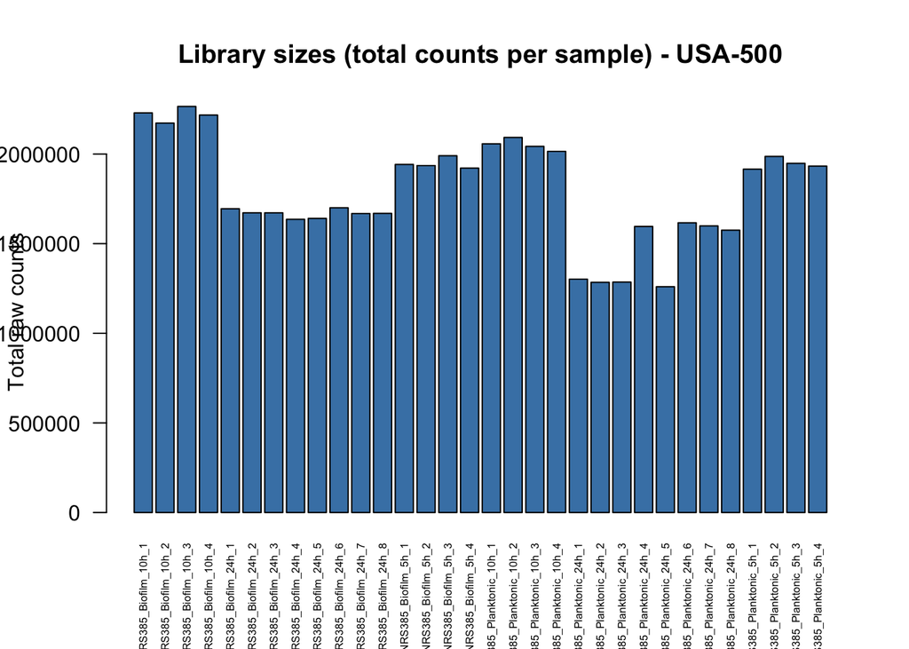

```r
options(scipen = 999)

barplot(colSums(count_genes),
        main   = paste0("Library sizes (total counts per sample) - ", strain),
        ylab   = "Total raw counts",
        xlab   = NULL,
        col    = "steelblue",
        las    = 2,
        cex.names = 0.5,
        names.arg = colnames(count_genes))
```

Samples differ in depth, which is exactly what the size factors further down correct for. What would worry you is one sample far below the rest: too few reads means too little information about that sample, whatever you do afterwards.

### Pre-filtering Low-count Genes

Genes with very few reads across all samples carry almost no information about differential expression. We remove genes that do not have at least 10 counts in a minimum number of samples - here the size of the smallest **lifestyle** group (16). Note this is stricter than DESeq2’s usual convention of the smallest design cell (4 samples in a lifestyle × time group): a gene expressed only in one lifestyle at one time point could be lost. With this dataset that cost is small, and the stricter filter keeps the later models stable.

Unlike the human genome, most bacterial genes are expressed under standard growth, so expect only a modest fraction to be filtered out.

**📘 Note: this step is optional, and it is not what controls your false positives.** The [DESeq2 vignette](https://bioconductor.org/packages/devel/bioc/vignettes/DESeq2/inst/doc/DESeq2.html) is explicit that pre-filtering is **not necessary** before running DESeq2. It is useful for three practical reasons: it shrinks the `dds` object, it speeds up model fitting, and it makes dispersion and MA plots easier to read, because genes with no information are not plotted.

What it does **not** do is take care of multiple testing. `results()` already applies **independent filtering** of its own: it searches for the mean-count threshold that yields the most significant genes at your chosen alpha, then sets `padj` to `NA` below it, so those genes leave the correction altogether. That happens whether or not you filtered here, which is why you could skip this step and rely on it instead. (A more refined option exists, IHW or Independent Hypothesis Weighting, which weights each gene by its mean count rather than discarding it, but you have to ask for it with `filterFun = ihw`.)

The count of 10 is the vignette’s suggestion for bulk RNA-seq, and its recommended number of samples is the size of the smallest group, so that a gene expressed in only one experimental group still survives. That is the convention the paragraph above departs from, deliberately.

```r
smallestGroupSize <- min(table(samples_info$lifestyle))

cat("Smallest lifestyle group size:", smallestGroupSize, "\n")
```

```
## Smallest lifestyle group size: 16
```

```r
cat("Filtering threshold          : at least 10 counts in", smallestGroupSize, "or more samples\n")
```

```
## Filtering threshold          : at least 10 counts in 16 or more samples
```

```r
keep <- rowSums(counts(dds) >= 10) >= smallestGroupSize
n_before <- nrow(dds)
dds  <- dds[keep, ]

cat("Genes before filtering:", n_before, "\n")
```

```
## Genes before filtering: 2928
```

```r
cat("Genes after  filtering:", nrow(dds), "\n")
```

```
## Genes after  filtering: 2275
```

```r
cat("Genes removed         :", sum(!keep), "\n")
```

```
## Genes removed         : 653
```

## Exploratory Data Analysis

In this section we do **not** perform statistical tests. The goal is **quality control:** check count distributions, detect technical outliers, and confirm that samples cluster as expected - and, specifically for this dataset, to see how strongly time point structures the data.

### Estimate Size Factors

Library sizes differ between samples due to technical variation in sequencing depth. `DESeq2`’s median-of-ratios normalisation corrects for this with a size factor per sample. Values close to 1.0 indicate balanced libraries; values far from 1.0 warrant investigation.

```r
dds <- estimateSizeFactors(dds)

sizeFactors(dds) %>%
  enframe(name = "sample", value = "size_factor") %>%
  kable(digits = 3, caption = "DESeq2 size factors per sample") %>%
  kable_styling(bootstrap_options = c("striped", "hover"), full_width = FALSE)
```

DESeq2 size factors per sample

| sample | size_factor |
| --- | --- |
| USA500_NRS385_Biofilm_10h_1 | 1.433 |
| USA500_NRS385_Biofilm_10h_2 | 1.397 |
| USA500_NRS385_Biofilm_10h_3 | 1.473 |
| USA500_NRS385_Biofilm_10h_4 | 1.424 |
| USA500_NRS385_Biofilm_24h_1 | 0.415 |
| USA500_NRS385_Biofilm_24h_2 | 0.403 |
| USA500_NRS385_Biofilm_24h_3 | 0.411 |
| USA500_NRS385_Biofilm_24h_4 | 0.398 |
| USA500_NRS385_Biofilm_24h_5 | 0.399 |
| USA500_NRS385_Biofilm_24h_6 | 0.416 |
| USA500_NRS385_Biofilm_24h_7 | 0.401 |
| USA500_NRS385_Biofilm_24h_8 | 0.412 |
| USA500_NRS385_Biofilm_5h_1 | 1.566 |
| USA500_NRS385_Biofilm_5h_2 | 1.564 |
| USA500_NRS385_Biofilm_5h_3 | 1.607 |
| USA500_NRS385_Biofilm_5h_4 | 1.548 |
| USA500_NRS385_Planktonic_10h_1 | 1.388 |
| USA500_NRS385_Planktonic_10h_2 | 1.430 |
| USA500_NRS385_Planktonic_10h_3 | 1.383 |
| USA500_NRS385_Planktonic_10h_4 | 1.379 |
| USA500_NRS385_Planktonic_24h_1 | 1.221 |
| USA500_NRS385_Planktonic_24h_2 | 1.192 |
| USA500_NRS385_Planktonic_24h_3 | 1.191 |
| USA500_NRS385_Planktonic_24h_4 | 1.481 |
| USA500_NRS385_Planktonic_24h_5 | 1.179 |
| USA500_NRS385_Planktonic_24h_6 | 1.500 |
| USA500_NRS385_Planktonic_24h_7 | 1.488 |
| USA500_NRS385_Planktonic_24h_8 | 1.476 |
| USA500_NRS385_Planktonic_5h_1 | 1.172 |
| USA500_NRS385_Planktonic_5h_2 | 1.229 |
| USA500_NRS385_Planktonic_5h_3 | 1.202 |
| USA500_NRS385_Planktonic_5h_4 | 1.195 |

### Distribution of Normalised Counts

Boxplots of log2-normalised counts per sample check that all samples have comparable expression distributions. After normalisation, boxes should overlap substantially. A sample that is a clear outlier in median or spread may indicate a failed library or mislabelled sample.

**📌 Remember:** These normalised counts are for visualisation only. Always feed DESeq2 **raw integer counts**.

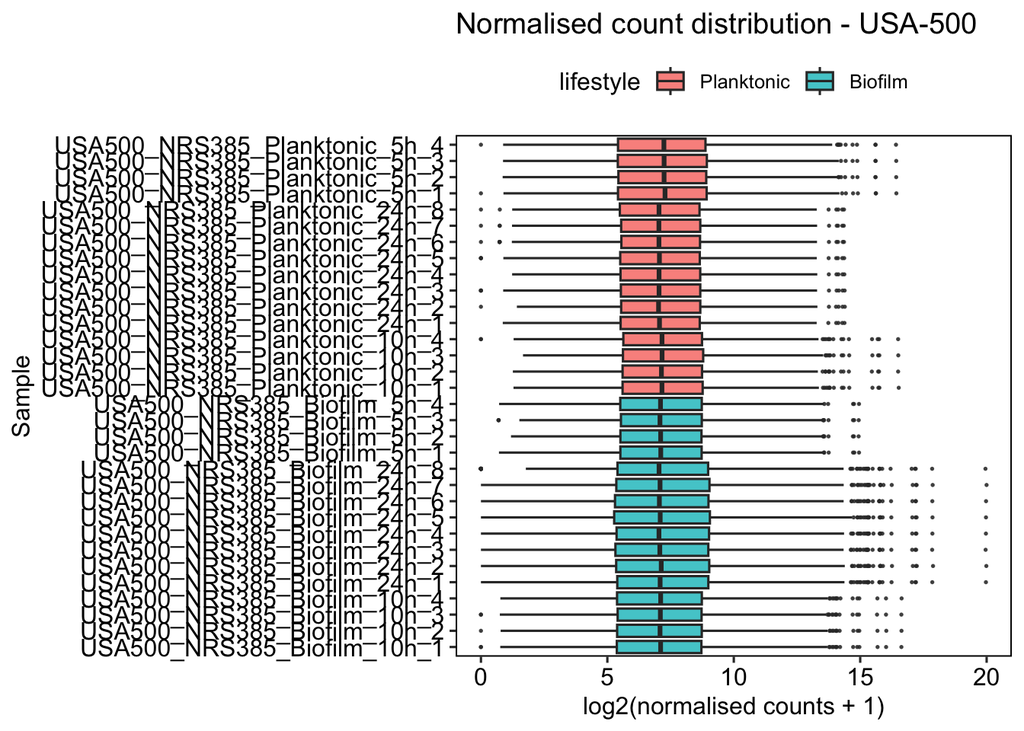

```r
normalized_counts <- counts(dds, normalized = TRUE)

counts_norm <- reshape2::melt(
  normalized_counts,
  varnames   = c("gene_id", "sample"),
  value.name = "counts"
)

counts_norm <- inner_join(
  counts_norm,
  as.data.frame(colData(dds)),
  by = "sample"
)

dir.create(file.path(results_dir, "plots"), recursive = TRUE, showWarnings = FALSE)

distribution <- ggplot(counts_norm,
                       aes(x    = sample,
                           y    = log2(counts + 1),
                           fill = lifestyle)) +
  geom_boxplot(outlier.size = 0.3, alpha = 0.8) +
  coord_flip() +
  theme_pubr(border = TRUE) +
  xlab("Sample") +
  ylab("log2(normalised counts + 1)") +
  ggtitle(paste0("Normalised count distribution - ", strain))

distribution
```

```r
ggsave(
  filename = file.path(results_dir, "plots", "normalised_count_distribution.png"),
  plot     = distribution,
  width    = 8,
  height   = 8,
  dpi      = 300
)
```

### Variance-Stabilising Transformation

The plots below compare samples to each other, and for that the counts need one more step. In raw or normalised counts the highly expressed genes vary far more in absolute terms than quiet ones, so they would dominate any distance or PCA calculation. The variance-stabilising transformation (VST) removes that dependence between a gene’s mean and its variance, so every gene contributes on a comparable scale ([Anders & Huber, 2010](https://doi.org/10.1186/gb-2010-11-10-r106)).

```r
vsd <- varianceStabilizingTransformation(dds, blind = TRUE)
```

**`blind = TRUE`** computes the transformation ignoring the experimental design. That is what you want for QC: an unbiased view of how samples relate, not one shaped by the answer you are hoping for. Use `blind = FALSE` only when the transformed values feed a model that already accounts for the design.

### Principal Component Analysis (PCA)

PCA reduces the high-dimensional expression space (one dimension per gene) to a few principal components capturing the largest sources of variance. Here it answers two questions at once: does lifestyle (biofilm vs planktonic) separate the samples, and how much of the structure is driven by time point?

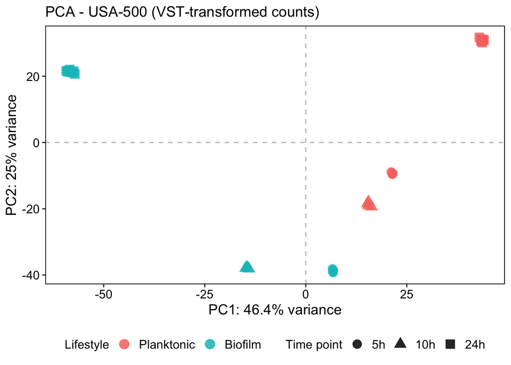

```r
pca_data <- plotPCA(vsd,
                    intgroup   = c("lifestyle", "timepoint"),
                    returnData = TRUE)

pct_var <- round(100 * attr(pca_data, "percentVar"), 1)

PCAPlot <- ggplot(pca_data, aes(x     = PC1,
                                y     = PC2,
                                color = lifestyle,
                                shape = timepoint)) +
  geom_point(size = 4, alpha = 0.85) +
  geom_hline(yintercept = 0, linetype = "dashed", alpha = 0.3) +
  geom_vline(xintercept = 0, linetype = "dashed", alpha = 0.3) +
  theme_pubr(border = TRUE) +
  theme(
    axis.text       = element_text(size = 12),
    axis.title      = element_text(size = 14),
    legend.text     = element_text(size = 12),
    legend.position = "bottom"
  ) +
  labs(
    x     = paste0("PC1: ", pct_var[1], "% variance"),
    y     = paste0("PC2: ", pct_var[2], "% variance"),
    title = paste0("PCA - ", strain, " (VST-transformed counts)"),
    color = "Lifestyle",
    shape = "Time point"
  )

PCAPlot
```

```r
ggsave(
  filename = file.path(results_dir, "plots", "PCA_Plot.png"),
  plot     = PCAPlot,
  width    = 8,
  height   = 6,
  dpi      = 300
)
```

**⭐ How to read this plot.** Each point is one sample; samples that are close have similar overall expression. Check the % variance printed on each axis first - it tells you how much of the story that axis carries. Then look at which axis separates **lifestyle** (colour) and which separates **time point** (shape). The paper reports that the biofilm–planktonic difference grows with culture age, strongest at 24 h - read the actual separation off *your* plot rather than assuming it. Script 02 builds directly on this structure: it models change over time and lifestyle adjusted for time, and saves the plain two-group comparison for a single, well-replicated time point (24 h) at the very end.

### Top Variable Genes Heatmap

Clustering the 50 most variable genes across samples gives a gene-level view of the structure in the data. Row-scaling (z-score per gene) is applied so that highly expressed genes do not visually dominate.

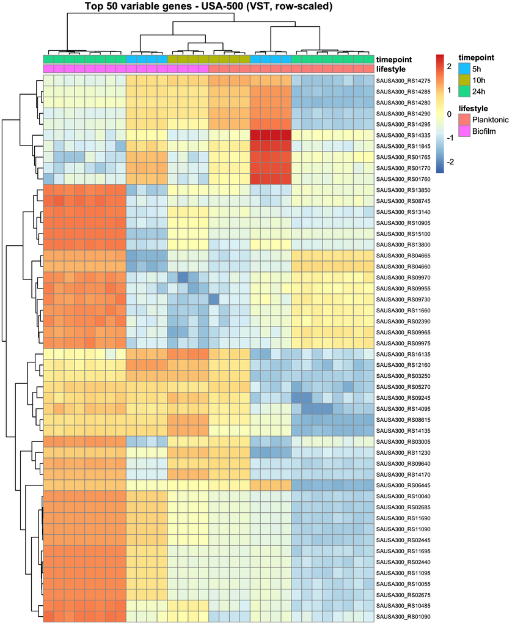

```r
topVarGenes <- head(order(rowVars(assay(vsd)), decreasing = TRUE), 50)

df_anno <- as.data.frame(colData(vsd)[, c("lifestyle", "timepoint"), drop = FALSE])

heat_plot <- pheatmap(
  assay(vsd)[topVarGenes, ],
  cluster_cols             = TRUE,
  cluster_rows             = TRUE,
  scale                    = "row",
  clustering_distance_rows = "euclidean",
  clustering_distance_cols = "euclidean",
  annotation_col           = df_anno,
  show_colnames            = FALSE,
  show_rownames            = TRUE,
  fontsize_row             = 7,
  main                     = paste0("Top 50 variable genes - ", strain, " (VST, row-scaled)")
)

heat_plot
```

```r
png(
  filename = file.path(results_dir, "plots", "heatmap_top50_variable.png"),
  width    = 9,
  height   = 11,
  units    = "in",
  res      = 300
)
heat_plot
dev.off()
```

**How to read this heatmap:**

- Each **row** is a gene, each **column** is a sample
- Colours show the **z-score** (row-scaled expression) - red = higher than average for that gene, blue = lower
- The **dendrograms** show hierarchical clustering - samples/genes that behave similarly are grouped together

**What to look for:**

- Clear colour blocks by lifestyle → biofilm vs planktonic has a strong, consistent transcriptional effect
- Whether samples split by time point first (a sign the time points are very different states)

## Summary

Before proceeding to differential expression, confirm the QC checks and record what you saw:

[output not shown]

*This QC loads all three time points so the structure is visible. Differential expression (script 02) keeps all of them: it models maturation over time and lifestyle adjusted for time, and uses the single 24 h time point only for the final hypothesis test. The two strains are never merged: they use different reference genomes and their locus tags are not comparable.*

**⭐ Important:** If any check fails, investigate the cause before running DESeq2. Proceeding with outlier samples or a mis-specified design will compromise all downstream results.

```r
# ── Export the full (all-timepoints) DDS for reference ────────────────────────
rds_dir <- file.path(results_dir, "rds")
dir.create(rds_dir, recursive = TRUE, showWarnings = FALSE)

dds_path <- file.path(rds_dir, paste0("dds_", strain_tag, "_all_timepoints.rds"))
saveRDS(dds, file = dds_path)

cat("✅ Full DDS saved to:", dds_path, "\n")
```

```
## ✅ Full DDS saved to: /Users/jasge/Documents/GitHub/dsp_27200/results/usa500/rds/dds_usa500_all_timepoints.rds
```

```r
cat("   Dimensions       :", nrow(dds), "genes ×", ncol(dds), "samples\n")
```

```
##    Dimensions       : 2275 genes × 32 samples
```

```r
cat("   Note             : this holds ALL time points. Script 02 subsets to the chosen one.\n")
```

```
##    Note             : this holds ALL time points. Script 02 subsets to the chosen one.
```

## Interpretation questions

1. Your output prints how many genes the filter removed. Pick one of them - a gene with almost no counts in any of your 32 samples - and suggest two possible reasons it is so quiet: one biological, one technical. (USA-500 groups: remember your reads were mapped to the USA300 genome.) How could you start telling the two apart with the data you already have?
2. These 50 genes are the most *variable* - not necessarily the most *important*. Could a gene that is essential for biofilm formation be missing from this heatmap? Give one reason how. (Hint: what does a count measure - and what does it miss?)